# Yuhan Primary Tumor RNA Seq - DESeq

Andrew Chen

October 31, 2024

```r
library(Biobase)
library(SummarizedExperiment)
library(tidyverse)
library(ggplot2)
library(DESeq2)
library(reactable)
library(cba)
library(pheatmap)
library(vennr)
library(EnsDb.Hsapiens.v86)
library(AnnotationDbi)
library(EnsDb.Mmusculus.v79)
library(ggrepel)

PATH <- file.path(Sys.getenv("MLAB"),"projects/brcameta/projects/exosome/4t1_primary_tumor/")
DPATH <- file.path(Sys.getenv("CBM"),"otherStudies/RNAseq/")
```

# Load Data

```r
invitro.filtered <- readRDS(file.path(PATH,"data/yuhan_invitro.rds"))
invivo.filtered <- readRDS(file.path(PATH,"data/yuhan_invivo.rds"))

invivo_ir_is <- invivo.filtered[, 1:14]
invivo_mirna <- invivo.filtered[, 15:21]
```

# DESeq Result Tables

> DESeq2 performs an internal normalization where geometric mean is calculated for each gene across all samples. The counts for a gene in each sample is then divided by this mean. The median of these ratios in a sample is the size factor for that sample. This procedure corrects for library size and RNA composition bias, which can arise for example when only a small number of genes are very highly expressed in one experiment condition but not in the other.

```r
invitro_dds <- DESeq2::DESeqDataSetFromMatrix(countData=round(invitro.filtered@assays@data$counts),
                                      colData=invitro.filtered@colData,
                                      design=~Condition)
invitro_dds <- estimateSizeFactors(invitro_dds)
invitro_dds$Condition <- relevel(invitro_dds$Condition, ref = "sc_miRNA4D")

invivo_iris_dds <- DESeq2::DESeqDataSetFromMatrix(countData=round(invivo_ir_is@assays@data$counts),
                                      colData=invivo_ir_is@colData,
                                      design=~Condition)
invivo_iris_dds <- estimateSizeFactors(invivo_iris_dds)
invivo_iris_dds$Condition <- relevel(invivo_iris_dds$Condition, ref = "Control")

invivo_mirna_dds <- DESeq2::DESeqDataSetFromMatrix(countData=round(invivo_mirna@assays@data$counts),
                                      colData=invivo_mirna@colData,
                                      design=~Condition)
invivo_mirna_dds <- estimateSizeFactors(invivo_mirna_dds)
invivo_mirna_dds$Condition <- relevel(invivo_mirna_dds$Condition, ref = "sc_miRNA")
```

```r
invitro_dds <- DESeq(invitro_dds)
invivo_iris_dds <- DESeq(invivo_iris_dds)
invivo_mirna_dds <- DESeq(invivo_mirna_dds)
```

## Invitro miR1514/scmiRNA

Summary of Different comparisons

```r
lfcs <- seq(0,1.0,0.1)
comp_df <- data.frame(lfcs = lfcs)
for (i in seq_along(lfcs)) {
  lfc <- lfcs[i]
  dds_res <- results(invitro_dds, alpha=0.05, lfcThreshold = lfc, contrast=c("Condition", "miR1514D", "sc_miRNA4D"))
  nPos <- sum((dds_res$padj < 0.05) & (dds_res$log2FoldChange > lfc), na.rm=TRUE)
  nNeg <- sum((dds_res$padj < 0.05) & (dds_res$log2FoldChange < -lfc), na.rm=TRUE)
  comp_df$nPos[i] = nPos
  comp_df$nNeg[i] = nNeg
}

comp_df
```

| lfcs | nPos | nNeg |
| --- | --- | --- |
| 0.0 | 667 | 592 |
| 0.1 | 260 | 200 |
| 0.2 | 102 | 77 |
| 0.3 | 41 | 35 |
| 0.4 | 24 | 15 |
| 0.5 | 19 | 6 |
| 0.6 | 12 | 3 |
| 0.7 | 9 | 3 |
| 0.8 | 6 | 2 |
| 0.9 | 6 | 2 |

[output cut: 1 more lines]

```r
dds_mir1514_scmiRNA_res <- results(invitro_dds, alpha=0.05, lfcThreshold = 0.1, contrast=c("Condition", "miR1514D", "sc_miRNA4D"))
dds_mir1514_scmiRNA_res_df <- dds_mir1514_scmiRNA_res[which(with(dds_mir1514_scmiRNA_res, padj<0.05)),] %>% as.data.frame
dds_mir1514_scmiRNA_res_df <- dds_mir1514_scmiRNA_res_df %>% dplyr::arrange(desc(log2FoldChange), padj)
symbols <- mapIds(EnsDb.Mmusculus.v79,
                  keys=rownames(dds_mir1514_scmiRNA_res_df),
                  column="SYMBOL",
                  keytype="GENEID")
dds_mir1514_scmiRNA_res_df$symbol <- symbols
write.csv(dds_mir1514_scmiRNA_res_df, file=file.path(PATH, "data/dds_invitro_mir1514D_scrna4D_diffanal.csv"), row.names = TRUE)
```

Table of Results

```r
reactable(dds_mir1514_scmiRNA_res_df, searchable = TRUE, filterable = TRUE)
```

|  | baseMean | log2FoldChange | lfcSE | stat | pvalue | padj | symbol |
| --- | --- | --- | --- | --- | --- | --- | --- |
| ENSMUSG00000094664 | 127.542420683066 | 21.8547228950364 | 4.12092063837691 | 5.27909290279486 | 1.29824973009224e-07 | 1.87873150596107e-05 | Rpl35a-ps6 |
| ENSMUSG00000039109 | 35.4232057616809 | 3.97540346603188 | 0.449882032704668 | 8.61426592818822 | 7.03911371401515e-18 | 5.90816277729672e-15 | F13a1 |
| ENSMUSG00000030218 | 77.1906011788169 | 2.42252261307447 | 0.25102298937078 | 9.25223071757754 | 2.19855528204499e-20 | 2.76798110009464e-17 | Mgp |
| ENSMUSG00000038463 | 166.301221332708 | 2.13807528695109 | 0.174877641528121 | 11.654293076816 | 2.18183582528332e-31 | 6.86732826007925e-28 | Olfml2b |
| ENSMUSG00000029307 | 69.0728355002512 | 2.02944345537126 | 0.251559784355311 | 7.66992013574814 | 1.72103475141861e-14 | 8.84194872947474e-12 | Dmp1 |
| ENSMUSG00000068245 | 88.7615929747412 | 1.64852083804095 | 0.222739432979014 | 6.95216297056324 | 3.59727483177216e-12 | 1.41530281662536e-09 | Phf11d |
| ENSMUSG00000005124 | 1064.68853407582 | 1.58026161079303 | 0.079166851092223 | 18.6979978408974 | 5.13986956708971e-78 | 6.47109578496595e-74 | Wisp1 |
| ENSMUSG00000038776 | 41.5539977745504 | 1.56603716459846 | 0.411356598135542 | 3.56390822766236 | 0.000365373743266077 | 0.0141540167006766 | Ephx1 |
| ENSMUSG00000085873 | 28.6648297485725 | 1.52571906828703 | 0.438010291179386 | 3.25498988721963 | 0.00113396403581227 | 0.0344014631587385 | Gm12750 |
| ENSMUSG00000035158 | 138.599492111794 | 1.44274477825383 | 0.179217248176873 | 7.49227427556887 | 6.76902805114473e-14 | 3.27777166015047e-11 | Mitf |

[output cut: 450 more lines]

## Invitro miR1454D/scmiRNA

Summary of Different comparisons

```r
lfcs <- seq(0,1.0,0.1)
comp_df <- data.frame(lfcs = lfcs)
for (i in seq_along(lfcs)) {
  lfc <- lfcs[i]
  dds_res <- results(invitro_dds, alpha=0.05, lfcThreshold = lfc, contrast=c("Condition", "miR1454D", "sc_miRNA4D"))
  nPos <- sum((dds_res$padj < 0.05) & (dds_res$log2FoldChange > lfc), na.rm=TRUE)
  nNeg <- sum((dds_res$padj < 0.05) & (dds_res$log2FoldChange < -lfc), na.rm=TRUE)
  comp_df$nPos[i] = nPos
  comp_df$nNeg[i] = nNeg
}

comp_df
```

| lfcs | nPos | nNeg |
| --- | --- | --- |
| 0.0 | 3589 | 3770 |
| 0.1 | 2683 | 2724 |
| 0.2 | 1906 | 1754 |
| 0.3 | 1352 | 986 |
| 0.4 | 937 | 559 |
| 0.5 | 672 | 305 |
| 0.6 | 472 | 161 |
| 0.7 | 352 | 100 |
| 0.8 | 245 | 56 |
| 0.9 | 186 | 35 |

[output cut: 1 more lines]

```r
dds_mir1454_scmiRNA_res <- results(invitro_dds, alpha=0.05, lfcThreshold = 0.1, contrast=c("Condition", "miR1454D", "sc_miRNA4D"))
dds_mir1454_scmiRNA_res_df <- dds_mir1454_scmiRNA_res[which(with(dds_mir1454_scmiRNA_res, padj<0.05)),] %>% as.data.frame
dds_mir1454_scmiRNA_res_df <- dds_mir1454_scmiRNA_res_df %>% dplyr::arrange(desc(log2FoldChange), padj)
symbols <- mapIds(EnsDb.Mmusculus.v79,
                  keys=rownames(dds_mir1454_scmiRNA_res_df),
                  column="SYMBOL",
                  keytype="GENEID")
dds_mir1454_scmiRNA_res_df$symbol <- symbols
write.csv(dds_mir1454_scmiRNA_res_df, file=file.path(PATH, "data/dds_invitro_mir1454D_scrna4D_diffanal.csv"), row.names = TRUE)
```

Table of Results

```r
reactable(dds_mir1454_scmiRNA_res_df, searchable = TRUE, filterable = TRUE)
```

|  | baseMean | log2FoldChange | lfcSE | stat | pvalue | padj | symbol |
| --- | --- | --- | --- | --- | --- | --- | --- |
| ENSMUSG00000086949 | 22.8034360338704 | 9.66121946362786 | 4.10991791132721 | 2.32637723426945 | 0.0199984350274705 | 0.0486748752192494 | Gm13066 |
| ENSMUSG00000070282 | 18.6278142799241 | 8.08208453454529 | 2.42547066034384 | 3.29094252305395 | 0.000998523129079738 | 0.00356630963227634 | 3000002C10Rik |
| ENSMUSG00000027744 | 22.1713471889586 | 6.5920595496459 | 1.26397345088154 | 5.13623094307726 | 2.80303172513908e-07 | 2.40729878715715e-06 | Stoml3 |
| ENSMUSG00000114138 | 28.205416820295 | 5.06258510820469 | 2.04927127236265 | 2.42163405847349 | 0.0154509008969297 | 0.0390054836251135 | NA |
| ENSMUSG00000016356 | 33.1422659174393 | 4.985866432106 | 0.53078164278791 | 9.20504033719625 | 3.41542923483043e-20 | 2.51302678025697e-18 | Col20a1 |
| ENSMUSG00000079707 | 33.8830849476163 | 4.97562040204657 | 1.39362191685317 | 3.49852448722666 | 0.000467840127349331 | 0.00183672126735437 | Tcte3 |
| ENSMUSG00000090173 | 60.0539634058217 | 4.91736575784326 | 0.484873267654838 | 9.9353090368194 | 2.9226827111423e-23 | 3.21667020738073e-21 | Fbxw10 |
| ENSMUSG00000022148 | 34.2399938022224 | 4.84896095020006 | 1.05093425671375 | 4.51879926823393 | 6.2191321382306e-06 | 3.92539631876656e-05 | Fyb |
| ENSMUSG00000101249 | 4071.10504817023 | 4.74434237653304 | 0.70530273441414 | 6.58489206112445 | 4.55215977217856e-11 | 7.85502457657741e-10 | Gm29216 |
| ENSMUSG00000078816 | 233.780192042121 | 4.71745462584535 | 0.250767673033223 | 18.4132769985612 | 1.02809311148903e-75 | 5.6426666914597e-72 | Prkcg |

[output cut: 5397 more lines]

## Invivo miRNA

Summary of Different comparisons

```r
lfcs <- seq(0,1.0,0.1)
comp_df <- data.frame(lfcs = lfcs)
for (i in seq_along(lfcs)) {
  lfc <- lfcs[i]
  dds_res <- results(invivo_mirna_dds, alpha=0.05, lfcThreshold = lfc, contrast=c("Condition", "miR_145", "sc_miRNA"))
  nPos <- sum((dds_res$padj < 0.05) & (dds_res$log2FoldChange > lfc), na.rm=TRUE)
  nNeg <- sum((dds_res$padj < 0.05) & (dds_res$log2FoldChange < -lfc), na.rm=TRUE)
  comp_df$nPos[i] = nPos
  comp_df$nNeg[i] = nNeg
}

comp_df
```

| lfcs | nPos | nNeg |
| --- | --- | --- |
| 0.0 | 36 | 0 |
| 0.1 | 22 | 0 |
| 0.2 | 13 | 0 |
| 0.3 | 10 | 0 |
| 0.4 | 9 | 0 |
| 0.5 | 7 | 0 |
| 0.6 | 6 | 0 |
| 0.7 | 5 | 0 |
| 0.8 | 5 | 0 |
| 0.9 | 5 | 0 |

[output cut: 1 more lines]

```r
dds_mir145_scmiRNA_res <- results(invivo_mirna_dds, alpha=0.05, lfcThreshold = 0, contrast=c("Condition", "miR_145", "sc_miRNA"))
dds_mir145_scmiRNA_res_df <- dds_mir145_scmiRNA_res[which(with(dds_mir145_scmiRNA_res, padj<0.05)),] %>% as.data.frame
dds_mir145_scmiRNA_res_df <- dds_mir145_scmiRNA_res_df %>% dplyr::arrange(desc(log2FoldChange), padj)
symbols <- mapIds(EnsDb.Mmusculus.v79,
                  keys=rownames(dds_mir145_scmiRNA_res_df),
                  column="SYMBOL",
                  keytype="GENEID")
dds_mir145_scmiRNA_res_df$symbol <- symbols
write.csv(dds_mir145_scmiRNA_res_df, file=file.path(PATH, "data/dds_invivo_mir145_scrna_diffanal.csv"), row.names = TRUE)
```

Table of Results

```r
reactable(dds_mir145_scmiRNA_res_df, searchable = TRUE, filterable = TRUE)
```

|  | baseMean | log2FoldChange | lfcSE | stat | pvalue | padj | symbol |
| --- | --- | --- | --- | --- | --- | --- | --- |
| ENSMUSG00000042092 | 57.675870709049 | 22.3499096936814 | 3.6787834107832 | 6.07535350631669 | 1.23714876008588e-09 | 7.81593341997812e-06 | Lce1c |
| ENSMUSG00000076613 | 53.4390407842971 | 22.2443431459366 | 3.67883774183344 | 6.04656815737967 | 1.47963654066602e-09 | 7.81593341997812e-06 | Ighg2b |
| ENSMUSG00000076614 | 1011.52493907878 | 12.2901795976734 | 3.17280081485478 | 3.87360578707994 | 0.000107236825980852 | 0.048553770894816 | Ighg1 |
| ENSMUSG00000043165 | 1656.61954062236 | 11.5091146325156 | 2.39372169586501 | 4.80804207623502 | 1.52415690609573e-06 | 0.00241533144908991 | Lor |
| ENSMUSG00000076609 | 1469.12851982219 | 7.81749578331527 | 1.57145329402682 | 4.97469177927846 | 6.53515373817532e-07 | 0.00115069534765405 | Igkc |
| ENSMUSG00000083012 | 131.560101508989 | 7.01201425158258 | 1.21940485627004 | 5.75035782047908 | 8.90547681975297e-09 | 2.82250182325251e-05 | Fam220a |
| ENSMUSG00000067149 | 335.970516433143 | 6.92753011436044 | 1.69157559170288 | 4.09531217424733 | 4.21599911924299e-05 | 0.025696514631786 | Igj |
| ENSMUSG00000089961 | 12.0435158531478 | 6.79938836095729 | 1.4373593740093 | 4.73047206141037 | 2.23998353948567e-06 | 0.00310315028939753 | Gm16567 |
| ENSMUSG00000028072 | 10.0859029987053 | 6.53610712430664 | 1.65287362673993 | 3.9543901109961 | 7.67301271888216e-05 | 0.0405314108520419 | Ntrk1 |
| ENSMUSG00000094686 | 665.805366539426 | 5.83895395275828 | 1.34661634296057 | 4.33601892868847 | 1.45086455544322e-05 | 0.0121009740053204 | Ccl21a |

[output cut: 26 more lines]

## Invivo IR/Control

Summary of Different comparisons

```r
lfcs <- seq(0,1.0,0.1)
comp_df <- data.frame(lfcs = lfcs)
for (i in seq_along(lfcs)) {
  lfc <- lfcs[i]
  dds_res <- results(invivo_iris_dds, alpha=0.05, lfcThreshold = lfc, contrast=c("Condition", "IR", "Control"))
  nPos <- sum((dds_res$padj < 0.05) & (dds_res$log2FoldChange > lfc), na.rm=TRUE)
  nNeg <- sum((dds_res$padj < 0.05) & (dds_res$log2FoldChange < -lfc), na.rm=TRUE)
  comp_df$nPos[i] = nPos
  comp_df$nNeg[i] = nNeg
}

comp_df
```

| lfcs | nPos | nNeg |
| --- | --- | --- |
| 0.0 | 183 | 54 |
| 0.1 | 72 | 14 |
| 0.2 | 30 | 10 |
| 0.3 | 15 | 6 |
| 0.4 | 9 | 6 |
| 0.5 | 3 | 5 |
| 0.6 | 1 | 4 |
| 0.7 | 1 | 3 |
| 0.8 | 1 | 3 |
| 0.9 | 1 | 2 |

[output cut: 1 more lines]

```r
dds_ir_control_res <- results(invivo_iris_dds, alpha=0.05, lfcThreshold = 0, contrast=c("Condition", "IR", "Control"))
dds_ir_control_res_df <- dds_ir_control_res[which(with(dds_ir_control_res, padj<0.05)),] %>% as.data.frame
dds_ir_control_res_df <- dds_ir_control_res_df %>% dplyr::arrange(desc(log2FoldChange), padj)
symbols <- mapIds(EnsDb.Mmusculus.v79,
                  keys=rownames(dds_ir_control_res_df),
                  column="SYMBOL",
                  keytype="GENEID")
dds_ir_control_res_df$symbol <- symbols
write.csv(dds_ir_control_res_df, file=file.path(PATH, "data/dds_invivo_ir_control_diffanal.csv"), row.names = TRUE)
```

Table of Results

```r
reactable(dds_ir_control_res_df, searchable = TRUE, filterable = TRUE)
```

|  | baseMean | log2FoldChange | lfcSE | stat | pvalue | padj | symbol |
| --- | --- | --- | --- | --- | --- | --- | --- |
| ENSMUSG00000026459 | 38.9214427136213 | 22.1651380200047 | 3.06175231605108 | 7.23936351866384 | 4.50795261637886e-13 | 7.14465410169885e-09 | Myog |
| ENSMUSG00000061462 | 193.148609054661 | 5.34552497410399 | 1.55961320265428 | 3.42746840370838 | 0.000609237197214491 | 0.0452886559384503 | Obscn |
| ENSMUSG00000018893 | 163.585586930271 | 4.85456549320017 | 1.30377202273444 | 3.7234772709868 | 0.000196497558514246 | 0.0249143184391383 | Mb |
| ENSMUSG00000020722 | 118.068131390168 | 4.82093585353445 | 1.31280113576111 | 3.67225143413627 | 0.000240422959269407 | 0.0274134063414449 | Cacng1 |
| ENSMUSG00000021933 | 16.8240881395968 | 4.63886797975158 | 1.06365210722024 | 4.36126431590011 | 1.29313038482649e-05 | 0.00379533767946575 | Gucy1b2 |
| ENSMUSG00000039462 | 8.85444163592173 | 4.33397316068292 | 1.16140847525473 | 3.73165277593859 | 0.000190227586960105 | 0.0243674720600227 | Col10a1 |
| ENSMUSG00000021798 | 133.266223064664 | 4.11904733655009 | 1.15169444211477 | 3.5765105621128 | 0.000348211253674112 | 0.0336512204846403 | Ldb3 |
| ENSMUSG00000039376 | 52.1260716024438 | 4.02274612864832 | 1.11871022358973 | 3.5958785785832 | 0.000323298580872069 | 0.033057801343493 | Synpo2l |
| ENSMUSG00000028773 | 31.5682564343132 | 3.77631070699998 | 1.10210310329243 | 3.42645864594572 | 0.000611506869255371 | 0.0452886559384503 | Fabp3 |
| ENSMUSG00000064179 | 78.717985284261 | 3.73115937780022 | 0.921565983387118 | 4.04871647289621 | 5.14992874183432e-05 | 0.0114768419809579 | Tnnt1 |

[output cut: 227 more lines]

## Invivo IR/IS

Summary of Different comparisons

```r
lfcs <- seq(0,1.0,0.1)
comp_df <- data.frame(lfcs = lfcs)
for (i in seq_along(lfcs)) {
  lfc <- lfcs[i]
  dds_res <- results(invivo_iris_dds, alpha=0.05, lfcThreshold = lfc, contrast=c("Condition", "IR", "IS"))
  nPos <- sum((dds_res$padj < 0.05) & (dds_res$log2FoldChange > lfc), na.rm=TRUE)
  nNeg <- sum((dds_res$padj < 0.05) & (dds_res$log2FoldChange < -lfc), na.rm=TRUE)
  comp_df$nPos[i] = nPos
  comp_df$nNeg[i] = nNeg
}

comp_df
```

| lfcs | nPos | nNeg |
| --- | --- | --- |
| 0.0 | 4 | 7 |
| 0.1 | 3 | 3 |
| 0.2 | 3 | 2 |
| 0.3 | 3 | 2 |
| 0.4 | 3 | 2 |
| 0.5 | 3 | 2 |
| 0.6 | 3 | 2 |
| 0.7 | 3 | 2 |
| 0.8 | 3 | 2 |
| 0.9 | 3 | 2 |

[output cut: 1 more lines]

```r
dds_iris_res <- results(invivo_iris_dds, alpha=0.05, lfcThreshold = 0, contrast=c("Condition", "IR", "IS"))
dds_iris_res_df <- dds_iris_res[which(with(dds_iris_res, padj<0.05)),] %>% as.data.frame
dds_iris_res_df <- dds_iris_res_df %>% dplyr::arrange(desc(log2FoldChange), padj)
symbols <- mapIds(EnsDb.Mmusculus.v79,
                  keys=rownames(dds_iris_res_df),
                  column="SYMBOL",
                  keytype="GENEID")
dds_iris_res_df$symbol <- symbols
write.csv(dds_iris_res_df, file=file.path(PATH, "data/dds_invivo_iris_diffanal.csv"), row.names = TRUE)
```

Table of Results

```r
reactable(dds_iris_res_df, searchable = TRUE, filterable = TRUE)
```

|  | baseMean | log2FoldChange | lfcSE | stat | pvalue | padj | symbol |
| --- | --- | --- | --- | --- | --- | --- | --- |
| ENSMUSG00000094420 | 53.8986995618131 | 23.9068262769904 | 3.53439703717786 | 6.76404660413575 | 1.34189887354574e-11 | 1.06338776234132e-07 | Igkv10-96 |
| ENSMUSG00000026390 | 17.7567975231119 | 22.1759136018712 | 3.53587663575967 | 6.27168758592923 | 3.5715566177578e-10 | 1.41514002087108e-06 | Marco |
| ENSMUSG00000094797 | 8.93157140867586 | 20.7934713144749 | 3.53862979432639 | 5.87613639262681 | 4.1995235773921e-09 | 1.33116498356175e-05 | Igkv6-15 |
| ENSMUSG00000104213 | 412.546779289133 | 7.91736039807064 | 1.91146323924898 | 4.1420416754556 | 3.44227772925862e-05 | 0.0495969633918362 | Ighd |
| ENSMUSG00000066878 | 513.941022801139 | -0.809596138861245 | 0.171769286415024 | -4.71327648707303 | 2.43765083195308e-06 | 0.00643905467260407 | Gm10184 |
| ENSMUSG00000090610 | 58.5629304189545 | -1.02022394356968 | 0.222519935542505 | -4.58486535636623 | 4.5427908137022e-06 | 0.00899983645079577 | Gm3571 |
| ENSMUSG00000109168 | 113.459850416756 | -1.40335501713366 | 0.300211105484223 | -4.67456063915467 | 2.9458358802237e-06 | 0.00666979326652364 | NA |
| ENSMUSG00000035557 | 120.455402359335 | -1.98529793328919 | 0.454131152695176 | -4.37164004606786 | 1.23316711142282e-05 | 0.0217160728321559 | Krt17 |
| ENSMUSG00000051159 | 147.208307797288 | -2.91223071243529 | 0.692786452131006 | -4.2036484741832 | 2.62646730581304e-05 | 0.0416268803298309 | Cited1 |
| ENSMUSG00000030653 | 37.4104246849256 | -22.5110402477877 | 3.53524247493752 | -6.36760856076374 | 1.91998150829764e-10 | 1.01432623083364e-06 | Pde2a |

[output cut: 1 more lines]

## Invivo IS/Control

Summary of Different comparisons

```r
lfcs <- seq(0,1.0,0.1)
comp_df <- data.frame(lfcs = lfcs)
for (i in seq_along(lfcs)) {
  lfc <- lfcs[i]
  dds_res <- results(invivo_iris_dds, alpha=0.05, lfcThreshold = lfc, contrast=c("Condition", "IS", "Control"))
  nPos <- sum((dds_res$padj < 0.05) & (dds_res$log2FoldChange > lfc), na.rm=TRUE)
  nNeg <- sum((dds_res$padj < 0.05) & (dds_res$log2FoldChange < -lfc), na.rm=TRUE)
  comp_df$nPos[i] = nPos
  comp_df$nNeg[i] = nNeg
}

comp_df
```

| lfcs | nPos | nNeg |
| --- | --- | --- |
| 0.0 | 10 | 3 |
| 0.1 | 3 | 3 |
| 0.2 | 3 | 3 |
| 0.3 | 2 | 3 |
| 0.4 | 2 | 3 |
| 0.5 | 2 | 3 |
| 0.6 | 1 | 3 |
| 0.7 | 1 | 3 |
| 0.8 | 1 | 3 |
| 0.9 | 1 | 3 |

[output cut: 1 more lines]

```r
dds_is_ctrl_res <- results(invivo_iris_dds, alpha=0.05, lfcThreshold = 0, contrast=c("Condition", "IS", "Control"))
dds_is_ctrl_res_df <- dds_is_ctrl_res[which(with(dds_is_ctrl_res, padj<0.05)),] %>% as.data.frame
dds_is_ctrl_res_df <- dds_is_ctrl_res_df %>% dplyr::arrange(desc(log2FoldChange), padj)
symbols <- mapIds(EnsDb.Mmusculus.v79,
                  keys=rownames(dds_is_ctrl_res_df),
                  column="SYMBOL",
                  keytype="GENEID")
dds_is_ctrl_res_df$symbol <- symbols
write.csv(dds_is_ctrl_res_df, file=file.path(PATH, "data/dds_invivo_is_ctrl_diffanal.csv"), row.names = TRUE)
```

Table of Results

```r
reactable(dds_is_ctrl_res_df, searchable = TRUE, filterable = TRUE)
```

|  | baseMean | log2FoldChange | lfcSE | stat | pvalue | padj | symbol |
| --- | --- | --- | --- | --- | --- | --- | --- |
| ENSMUSG00000026459 | 38.9214427136213 | 18.6336563700395 | 3.06871941331504 | 6.07212777068794 | 1.26226434079729e-09 | 6.66854251243207e-06 | Myog |
| ENSMUSG00000031891 | 60.780551892769 | 2.41102032925213 | 0.561575506006195 | 4.29331461836502 | 1.76025294028688e-05 | 0.0279076278319837 | Hsd11b2 |
| ENSMUSG00000000120 | 259.87954664435 | 2.27648011160329 | 0.466714841826172 | 4.87766813392055 | 1.07347335173934e-06 | 0.00283557985861947 | Ngfr |
| ENSMUSG00000016942 | 413.205981067417 | 2.19245793812354 | 0.512985369791826 | 4.27391903791186 | 1.92066801911698e-05 | 0.0279076278319837 | Tmprss6 |
| ENSMUSG00000028699 | 54.9090782412352 | 1.45004999956411 | 0.346139874838964 | 4.18920241488712 | 2.7993661909984e-05 | 0.0345955810563785 | Tspan1 |
| ENSMUSG00000026639 | 1309.48734595798 | 1.35894652055905 | 0.196098639262886 | 6.92991305634343 | 4.21099342913955e-12 | 6.67400348584327e-08 | Lamb3 |
| ENSMUSG00000024512 | 64.5537603465853 | 1.20444288615021 | 0.281936245414237 | 4.27203988753049 | 1.93692918260976e-05 | 0.0279076278319837 | Dynap |
| ENSMUSG00000028364 | 11150.6198183986 | 1.19501738869264 | 0.269556377812633 | 4.43327439843877 | 9.28126188343929e-06 | 0.0210141027986613 | Tnc |
| ENSMUSG00000059089 | 658.253839421764 | 0.942013444299466 | 0.216034211488502 | 4.3604827115524 | 1.29775835819038e-05 | 0.0257102152736992 | Fcgr4 |
| ENSMUSG00000026479 | 9304.20361272084 | 0.676891932760958 | 0.161699239854286 | 4.18611697476706 | 2.83767148547492e-05 | 0.0345955810563785 | Lamc2 |

[output cut: 3 more lines]

# Signature Comparison

```r
# Preparing Signatures
invitro_1514_sc_up <- dds_mir1514_scmiRNA_res_df %>% dplyr::filter(log2FoldChange > 0) %>% rownames
invitro_1454_sc_up <- dds_mir1454_scmiRNA_res_df %>% dplyr::filter(log2FoldChange > 0) %>% rownames
invivo_miR_sc_up <- dds_mir145_scmiRNA_res_df %>% dplyr::filter(log2FoldChange > 0) %>% rownames
invivo_ir_is_up <- dds_iris_res_df %>% dplyr::filter(log2FoldChange > 0) %>% rownames
invivo_ir_ctrl_up <- dds_ir_control_res_df %>% dplyr::filter(log2FoldChange > 0) %>% rownames
invivo_is_ctrl_up <- dds_is_ctrl_res_df %>% dplyr::filter(log2FoldChange > 0) %>% rownames

invitro_1514_sc_dn <- dds_mir1514_scmiRNA_res_df %>% dplyr::filter(log2FoldChange < 0) %>% rownames
invitro_1454_sc_dn <- dds_mir1454_scmiRNA_res_df %>% dplyr::filter(log2FoldChange < 0) %>% rownames
invivo_miR_sc_dn <- dds_mir145_scmiRNA_res_df %>% dplyr::filter(log2FoldChange < 0) %>% rownames
invivo_ir_is_dn <- dds_iris_res_df %>% dplyr::filter(log2FoldChange < 0) %>% rownames
invivo_ir_ctrl_dn <- dds_ir_control_res_df %>% dplyr::filter(log2FoldChange < 0) %>% rownames
invivo_is_ctrl_dn <- dds_is_ctrl_res_df %>% dplyr::filter(log2FoldChange < 0) %>% rownames

# Combining labels
all_sigs <- list(mir1514_sc_up=invitro_1514_sc_up, mir1454_sc_up=invitro_1454_sc_up, miR_sc_up=invivo_miR_sc_up, ir_is_up=invivo_ir_is_up, ir_ctrl_up=invivo_ir_ctrl_up, is_ctrl_up = invivo_is_ctrl_up,
                 mir1514_sc_dn=invitro_1514_sc_dn, mir1454_sc_dn=invitro_1454_sc_dn, miR_sc_dn=invivo_miR_sc_dn, ir_is_dn=invivo_ir_is_dn, ir_ctrl_dn=invivo_ir_ctrl_dn, is_ctrl_dn = invivo_is_ctrl_dn)
```

```r
vennr(all_sigs)
```

[interactive chart not shown]

# Heatmaps

```r
hcopt <- function(d, HC=NULL, method = "ward.D", members = NULL){
  require("cba")
  if ( is.null(HC) ) {
    HC <- hclust(d,method=method,members=members)
  }
  #optimal leaf ordering
  ORD <- cba::order.optimal(d,merge=HC$merge)
  HC$merge <- ORD$merge
  HC$order <- ORD$order
  HC
}
```

## Invitro miR1514/scmiRNA

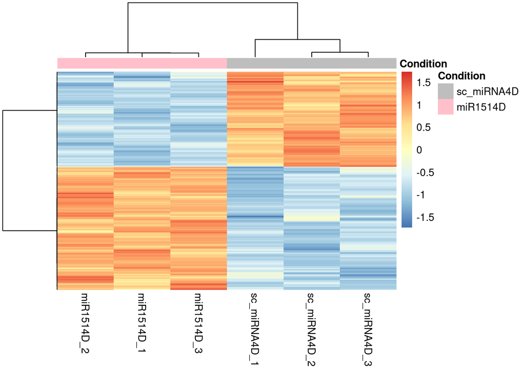

```r
## Heatmap for the top 3000
dat_flt <-
  invitro.filtered[c(invitro_1514_sc_up, invitro_1514_sc_dn),c(7:9,14:16)]
## column annotation
annot <- invitro.filtered@colData %>% data.frame() %>% dplyr::select("Condition")
rownames(annot) <- colnames(invitro.filtered@assays@data$counts)
annot_col <- list(Condition=c(sc_miRNA4D="gray",miR1514D="pink"))
library(cba)
hc_row <- hcopt(as.dist(1-cor(t(dat_flt@assays@data$rle_log2))),method="ward.D")
hc_col <- hcopt(dist(t(dat_flt@assays@data$rle_log2)),method="ward.D")

pheatmap(dat_flt@assays@data$rle_log2,
         annotation_col = annot,
         annotation_colors = annot_col,
         cluster_rows=hc_row,
         cluster_cols=hc_col,
         show_rownames = FALSE,
         show_colnames = TRUE,
         scale = "row")
```

## Invitro miR1454/scmiRNA

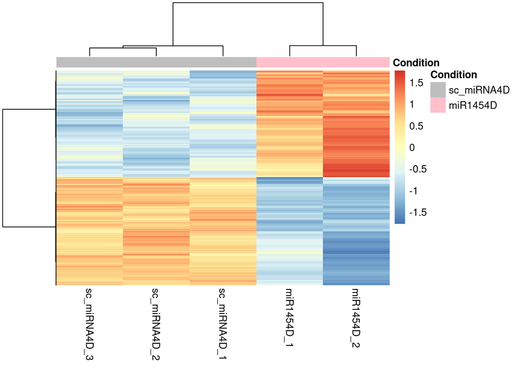

```r
## Heatmap for the top 3000
dat_flt <-
  invitro.filtered[c(invitro_1454_sc_up, invitro_1454_sc_dn),c(3,10,14:16)]
## column annotation
annot <- invitro.filtered@colData %>% data.frame() %>% dplyr::select("Condition")
rownames(annot) <- colnames(invitro.filtered@assays@data$counts)
annot_col <- list(Condition=c(sc_miRNA4D="gray",miR1454D="pink"))
library(cba)
hc_row <- hcopt(as.dist(1-cor(t(dat_flt@assays@data$rle_log2))),method="ward.D")
hc_col <- hcopt(dist(t(dat_flt@assays@data$rle_log2)),method="ward.D")

pheatmap(dat_flt@assays@data$rle_log2,
         annotation_col = annot,
         annotation_colors = annot_col,
         cluster_rows=hc_row,
         cluster_cols=hc_col,
         show_rownames = FALSE,
         show_colnames = TRUE,
         scale = "row")
```

## Invivo miRNA

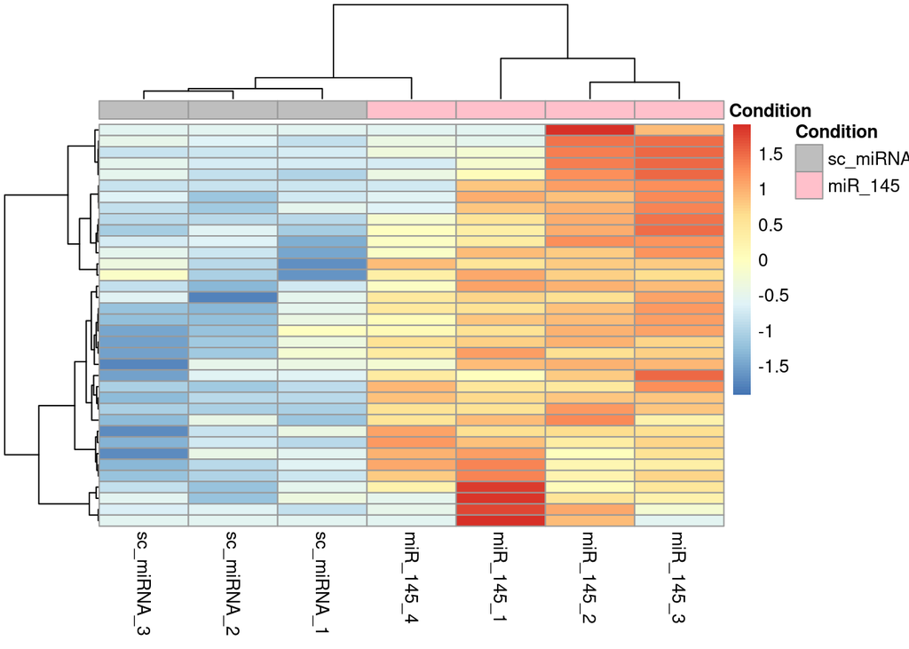

```r
## Heatmap for the top 3000
dat_flt <-
  invivo.filtered[c(invivo_miR_sc_up, invivo_miR_sc_dn),15:21]
## column annotation
annot <- invivo.filtered@colData %>% data.frame() %>% dplyr::select("Condition")
rownames(annot) <- colnames(invivo.filtered@assays@data$counts)
annot_col <- list(Condition=c(sc_miRNA="gray",miR_145="pink"))
library(cba)
hc_row <- hcopt(as.dist(1-cor(t(dat_flt@assays@data$rle_log2))),method="ward.D")
hc_col <- hcopt(dist(t(dat_flt@assays@data$rle_log2)),method="ward.D")

pheatmap(dat_flt@assays@data$rle_log2,
         annotation_col = annot,
         annotation_colors = annot_col,
         cluster_rows=hc_row,
         cluster_cols=hc_col,
         show_rownames = FALSE,
         show_colnames = TRUE,
         scale = "row")
```

## Invivo IR/IS

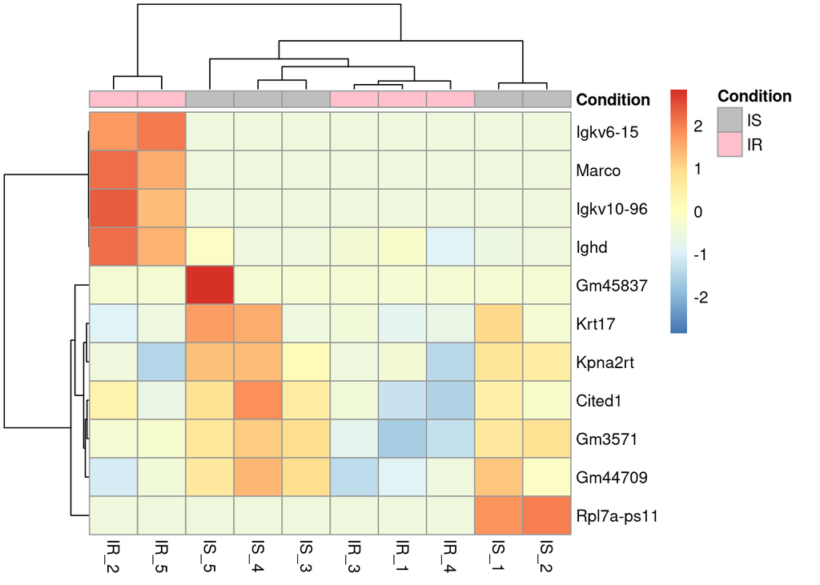

```r
## Heatmap for the top 3000
dat_flt <-
  invivo.filtered[c(invivo_ir_is_up, invivo_ir_is_dn),5:14]
rownames(dat_flt@assays@data$rle_log2) <- rowData(dat_flt)$gene_name
## column annotation
annot <- invivo.filtered@colData %>% data.frame() %>% dplyr::select("Condition")
rownames(annot) <- colnames(invivo.filtered@assays@data$counts)
annot_col <- list(Condition=c(IS="gray",IR="pink"))
library(cba)
hc_row <- hcopt(as.dist(1-cor(t(dat_flt@assays@data$rle_log2))),method="ward.D")
hc_col <- hcopt(dist(t(dat_flt@assays@data$rle_log2)),method="ward.D")

pheatmap(dat_flt@assays@data$rle_log2,
         annotation_col = annot,
         annotation_colors = annot_col,
         cluster_rows=hc_row,
         cluster_cols=hc_col,
         show_rownames = TRUE,
         show_colnames = TRUE,
         scale = "row")
```

## Invivo IR/Control

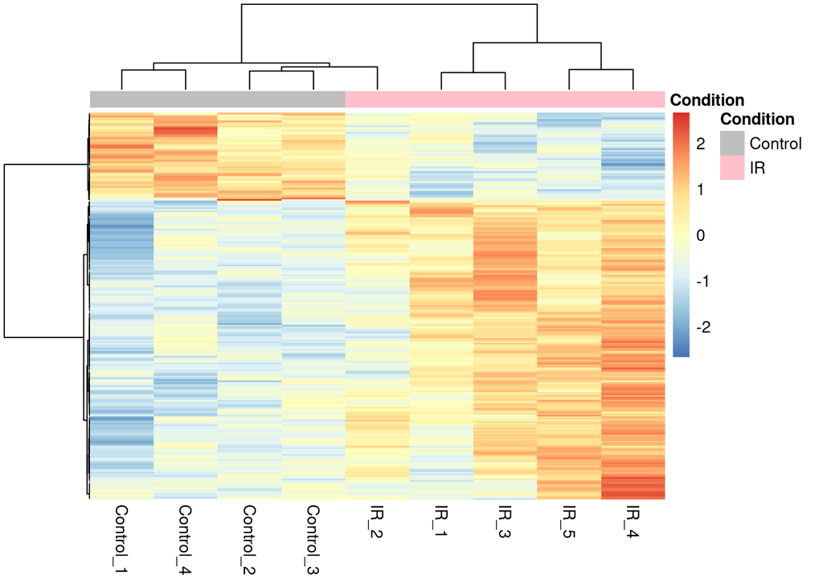

```r
## Heatmap for the top 3000
dat_flt <-
  invivo.filtered[c(invivo_ir_ctrl_up, invivo_ir_ctrl_dn), 1:9]
## column annotation
annot <- invivo.filtered@colData %>% data.frame() %>% dplyr::select("Condition")
rownames(annot) <- colnames(invivo.filtered@assays@data$counts)
annot_col <- list(Condition=c(Control="gray",IR="pink"))
library(cba)
hc_row <- hcopt(as.dist(1-cor(t(dat_flt@assays@data$rle_log2))),method="ward.D")
hc_col <- hcopt(dist(t(dat_flt@assays@data$rle_log2)),method="ward.D")

pheatmap(dat_flt@assays@data$rle_log2,
         annotation_col = annot,
         annotation_colors = annot_col,
         cluster_rows=hc_row,
         cluster_cols=hc_col,
         show_rownames = FALSE,
         show_colnames = TRUE,
         scale = "row")
```

## Invivo IS/Control

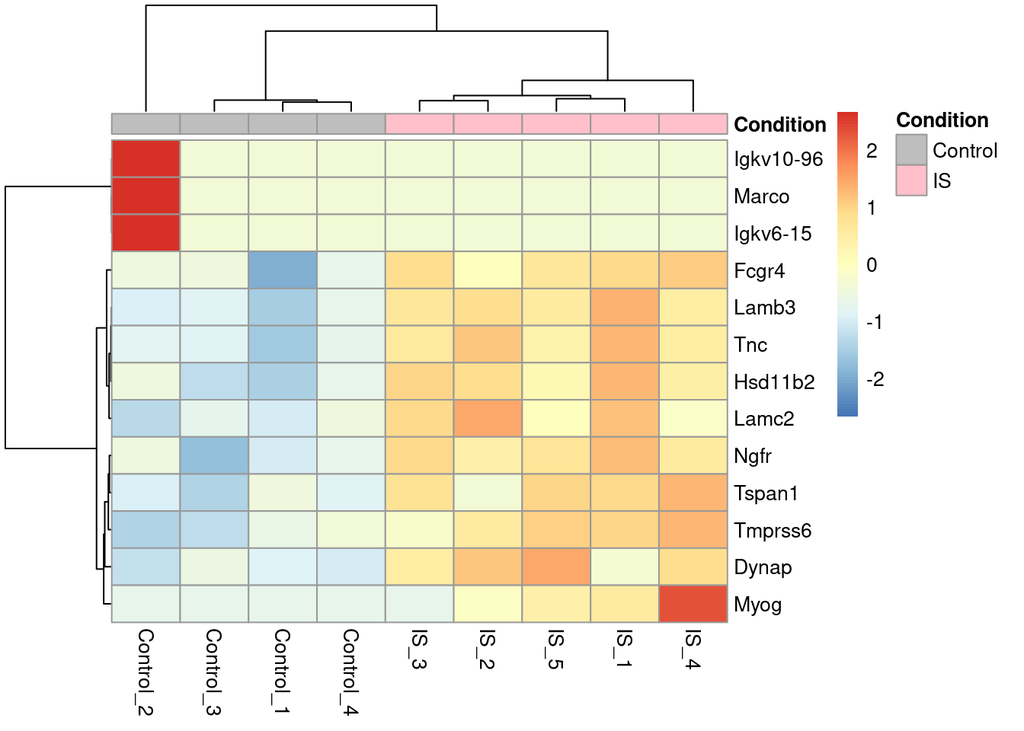

```r
## Heatmap for the top 3000
dat_flt <-
  invivo.filtered[c(invivo_is_ctrl_up, invivo_is_ctrl_dn), c(1:4, 10:14)]
rownames(dat_flt@assays@data$rle_log2) <- rowData(dat_flt)$gene_name
## column annotation
annot <- invivo.filtered@colData %>% data.frame() %>% dplyr::select("Condition")
rownames(annot) <- colnames(invivo.filtered@assays@data$counts)
annot_col <- list(Condition=c(Control="gray",IS="pink"))
library(cba)
hc_row <- hcopt(as.dist(1-cor(t(dat_flt@assays@data$rle_log2))),method="ward.D")
hc_col <- hcopt(dist(t(dat_flt@assays@data$rle_log2)),method="ward.D")

pheatmap(dat_flt@assays@data$rle_log2,
         annotation_col = annot,
         annotation_colors = annot_col,
         cluster_rows=hc_row,
         cluster_cols=hc_col,
         show_rownames = TRUE,
         show_colnames = TRUE,
         scale = "row")
```

# Volcano Plot

```r
dds_iris_res
```

```
## log2 fold change (MLE): Condition IR vs IS
## Wald test p-value: Condition IR vs IS
## DataFrame with 15950 rows and 6 columns
##                     baseMean log2FoldChange     lfcSE       stat     pvalue
##                    <numeric>      <numeric> <numeric>  <numeric>  <numeric>
## ENSMUSG00000000001  3292.987      0.1570783  0.139080   1.129410 0.25872507
## ENSMUSG00000000028   717.133     -0.4852108  0.161741  -2.999922 0.00270049
## ENSMUSG00000000031 20241.095      0.2764838  0.315363   0.876716 0.38064069
## ENSMUSG00000000056   714.612      0.3489024  0.249217   1.399993 0.16151531
## ENSMUSG00000000058   724.528      0.0562471  0.127410   0.441467 0.65887514
## ...                      ...            ...       ...        ...        ...
## ENSMUSG00000121914 201.82350      0.0170376  0.211160  0.0806853   0.935692
## ENSMUSG00002075453   4.18478      0.4967403  3.435348  0.1445968         NA
## ENSMUSG00002075795  18.21644     -0.2009234  0.459574 -0.4371946   0.661970
## ENSMUSG00002076083 485.59681      0.0727645  0.178103  0.4085536   0.682867
## ENSMUSG00002076161  61.30437     -0.6167099  0.281334 -2.1920898   0.028373
##                         padj
##                    <numeric>
## ENSMUSG00000000001  0.790143
## ENSMUSG00000000028  0.254762
## ENSMUSG00000000031  0.821517
## ENSMUSG00000000056  0.758734
## ENSMUSG00000000058  0.913348
## ...                      ...
## ENSMUSG00000121914  0.987641
## ENSMUSG00002075453        NA
## ENSMUSG00002075795  0.914854
## ENSMUSG00002076083  0.920920
## ENSMUSG00002076161  0.605228
```

```r
symbols <- mapIds(EnsDb.Mmusculus.v79,
                  keys=rownames(dds_iris_res),
                  column="SYMBOL",
                  keytype="GENEID")
dds_iris_res$symbol <- symbols
```

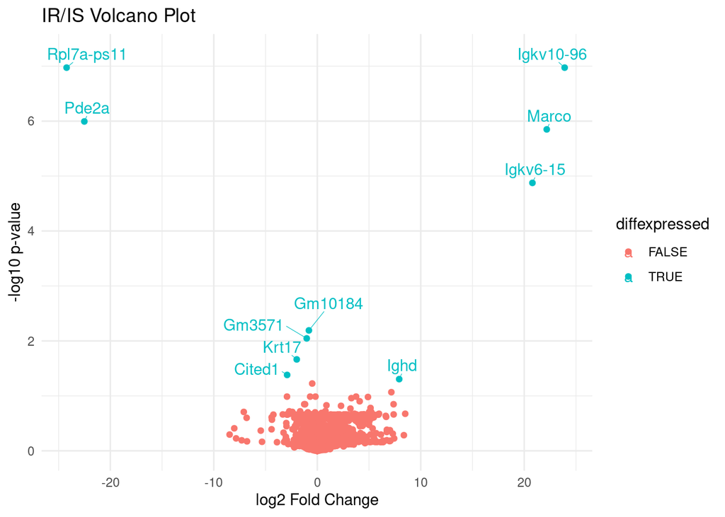

```r
dds_iris_res %>%
  as.data.frame %>%
  dplyr::filter(!is.na(symbol) & !is.na(padj)) %>%
  dplyr::mutate(
    diffexpressed = if_else(
      padj < 0.05,
      TRUE,
      FALSE)) %>%
  dplyr::mutate(
    label = if_else(
      diffexpressed,
      symbol,
      ""
    )
  ) %>%
  ggplot(aes(x = log2FoldChange, y = -log10(padj), color = diffexpressed, label = label)) +
  geom_point() +
  geom_text_repel(min.segment.length = 0,
                  nudge_x = 0.25,
                  nudge_y = 0.25,
                  segment.size = 0.2) +
  theme_minimal() +
  labs(title = "IR/IS Volcano Plot",
       x = "log2 Fold Change",
       y = "-log10 p-value")
```